# IDG-DREAM Round 2 Ensemble Analysis

11 June, 2019

Round 2 of the IDG-DREAM Challenge gave participants two opportunities to predict 394 Kd values between 25 compounds and 207 kinases.

First, import packages, scoring functions, and challenge data.

#Spearman ensemble

```r
best_spearman_by_team <- leaderboard %>%
  filter(submitterId %in% submitted_docker_and_methods) %>%
  group_by(submitterId) %>%
  top_n(1, spearman) %>%
  ungroup() %>%
  arrange(-spearman) %>%
  add_column(rank = group_indices(., -spearman)) %>%
  mutate(objectId = as.character(objectId))

paths <- map_chr(best_spearman_by_team$id, get_path)
names(paths) <- best_spearman_by_team$objectId
```

Then we map all of these ranked prediction files and gather the prediction values into one tidy data frame.

```r
preds <- pmap(.l = list(path = paths, renameColname = 'pKd_[M]_pred', newName = names(paths)), .f = challengescoring:::.read_and_rename) %>%
  purrr::reduce(left_join) %>%
  tidyr::gather(objectId, pred, -Compound_SMILES, -Compound_InchiKeys, -Compound_Name, -UniProt_Id, -Entrez_Gene_Symbol, -DiscoveRx_Gene_Symbol) %>%
  filter(pred<20) %>%
  left_join(select(best_spearman_by_team, objectId, rank))
```

```r
median_preds <- lapply(unique(preds$rank), function(i){
   colname <- paste0('spearman_median_ensemble_',i)
   foo <- preds %>%
     filter(rank <= i) %>%
     group_by(Compound_SMILES, Compound_InchiKeys, Compound_Name, UniProt_Id, Entrez_Gene_Symbol,
              DiscoveRx_Gene_Symbol) %>%
     summarize(!!colname := median(pred)) %>%
     ungroup()
   foo
 }) %>% reduce(left_join)
```

```r
median_test <- left_join(median_preds, gold)

median_results_spearman <- apply(median_test %>% select(7:(ncol(median_test)-1),`pKd_[M]`), 2, spearman_py,
                                 gold = median_test$`pKd_[M]`) %>%
  as.data.frame() %>%
  rownames_to_column("ensemble_model") %>%
  filter(ensemble_model != "pKd_[M]") %>%
  mutate(iteration = str_extract(ensemble_model, "[:digit:]+")) %>%
  mutate(ensemble_model = str_extract(ensemble_model, "[:alpha:]+_[:alpha:]+_[:alpha:]+"))
```

ranked (weighted mean) spearman:

```r
rank_preds <- lapply(unique(preds$rank), function(i){
   colname <- paste0('spearman_rank_ensemble_',i)
   foo <- preds %>%
     filter(rank <= i) %>%
     mutate(predrankweight = (pred*(21-rank))/sum((21-i):20)) %>%
     group_by(Compound_SMILES, Compound_InchiKeys, Compound_Name, UniProt_Id, Entrez_Gene_Symbol,
              DiscoveRx_Gene_Symbol) %>%
     summarize(!!colname := sum(predrankweight)) %>%
     ungroup()
   foo
 }) %>% reduce(left_join)

rank_test <- left_join(rank_preds, gold)

rank_results_spearman <- apply(rank_test %>% select(7:(ncol(rank_test)-1),`pKd_[M]`), 2, spearman_py,
                                 gold = rank_test$`pKd_[M]`) %>%
  as.data.frame() %>%
  rownames_to_column("ensemble_model") %>%
  filter(ensemble_model != "pKd_[M]") %>%
  mutate(iteration = str_extract(ensemble_model, "[:digit:]+")) %>%
  mutate(ensemble_model = str_extract(ensemble_model, "[:alpha:]+_[:alpha:]+_[:alpha:]+"))
```

mean:

```r
mean_preds_sp <- lapply(unique(preds$rank), function(i){
   colname <- paste0('spearman_mean_ensemble_',i)
   foo <- preds %>%
     filter(rank <= i) %>%
     group_by(Compound_SMILES, Compound_InchiKeys, Compound_Name, UniProt_Id, Entrez_Gene_Symbol,
              DiscoveRx_Gene_Symbol) %>%
     summarize(!!colname := mean(pred)) %>%
     ungroup()
   foo
 }) %>% reduce(left_join)

mean_test <- left_join(mean_preds_sp, gold)

mean_results_spearman <- apply(mean_test %>% select(7:(ncol(mean_test)-1),`pKd_[M]`), 2, spearman_py,
                                 gold = mean_test$`pKd_[M]`) %>%
  as.data.frame() %>%
  rownames_to_column("ensemble_model") %>%
  filter(ensemble_model != "pKd_[M]") %>%
  mutate(iteration = str_extract(ensemble_model, "[:digit:]+")) %>%
  mutate(ensemble_model = str_extract(ensemble_model, "[:alpha:]+_[:alpha:]+_[:alpha:]+"))
```

Now stick them all together into one data frame and plot them to get an idea of relative performance.

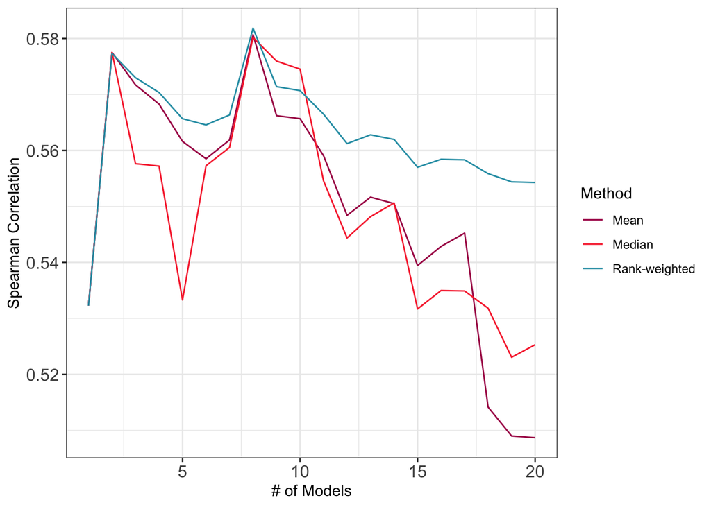

```r
ensemble_scores <- bind_rows(median_results_spearman, mean_results_spearman, rank_results_spearman)  %>%
  set_names(c("ensemble_model", "score", "iteration")) %>%
  mutate(iteration = as.numeric(iteration))

ggplot(data = ensemble_scores %>% filter(grepl("*spearman*", ensemble_model))) +
  geom_line(aes(x= iteration, y = score, color = ensemble_model)) +
  scale_color_manual(values = c("#AA1155","#F8333C","#2B9EB3"),
                     name = "Method",
                     labels = c("Mean", "Median", "Rank-weighted")) +
  theme_bw() +
  labs(x = "# of Models", y = "Spearman Correlation") +
  theme(axis.text = element_text(size = 12))
```

plot the best vs gold standard:

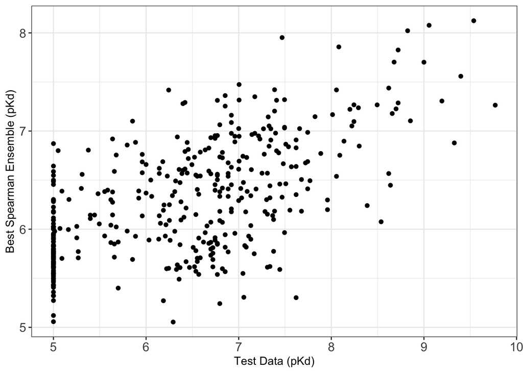

```r
best_ens_vs_gold <- mean_preds_sp %>%
  left_join(gold) %>%
  select(1:6, spearman_mean_ensemble_8, `pKd_[M]`) %>%
  mutate(gold = `pKd_[M]`)

ggplot(data = best_ens_vs_gold) +
  geom_point(aes(x= gold, y= spearman_mean_ensemble_8)) +
  theme_bw() +
  labs(x = "Test Data (pKd)", y = "Best Spearman Ensemble (pKd)") +
  theme(axis.text = element_text(size = 12))
```

##RMSE

median:

```r
best_rmse_by_team <- leaderboard %>%
  filter(submitterId %in% submitted_docker_and_methods) %>%
  group_by(submitterId) %>%
  top_n(1, -rmse) %>%
  ungroup() %>%
  arrange(-rmse) %>%
  add_column(rank = group_indices(., rmse)) %>%
  mutate(objectId = as.character(objectId))

paths <- map_chr(best_rmse_by_team$id, get_path)
names(paths) <- best_rmse_by_team$objectId

preds <- pmap(.l = list(path = paths, renameColname = 'pKd_[M]_pred', newName = names(paths)), .f = challengescoring:::.read_and_rename) %>%
  purrr::reduce(left_join) %>%
  tidyr::gather(objectId, pred, -Compound_SMILES, -Compound_InchiKeys, -Compound_Name, -UniProt_Id, -Entrez_Gene_Symbol, -DiscoveRx_Gene_Symbol) %>%
  filter(pred<20) %>%
  left_join(select(best_rmse_by_team, objectId, rank))

median_preds <- lapply(unique(preds$rank), function(i){
   colname <- paste0('rmse_median_ensemble_',i)
   foo <- preds %>%
     filter(rank <= i) %>%
     group_by(Compound_SMILES, Compound_InchiKeys, Compound_Name, UniProt_Id, Entrez_Gene_Symbol,
              DiscoveRx_Gene_Symbol) %>%
     summarize(!!colname := median(pred)) %>%
     ungroup()
   foo
 }) %>% reduce(left_join)

median_test <- left_join(median_preds, gold)

median_results_rmse <- apply(median_test %>% select(7:(ncol(median_test)-1),`pKd_[M]`), 2, rmse_py,
                                 gold = median_test$`pKd_[M]`) %>%
  as.data.frame() %>%
  rownames_to_column("ensemble_model") %>%
  filter(ensemble_model != "pKd_[M]") %>%
  mutate(iteration = str_extract(ensemble_model, "[:digit:]+")) %>%
  mutate(ensemble_model = str_extract(ensemble_model, "[:alpha:]+_[:alpha:]+_[:alpha:]+"))
```

ranked (weighted mean) spearman:

```r
rank_preds <- lapply(unique(preds$rank), function(i){
   colname <- paste0('rmse_rank_ensemble_',i)
   foo <- preds %>%
     filter(rank <= i) %>%
     mutate(predrankweight = (pred*(21-rank))/sum((21-i):20)) %>%
     group_by(Compound_SMILES, Compound_InchiKeys, Compound_Name, UniProt_Id, Entrez_Gene_Symbol,
              DiscoveRx_Gene_Symbol) %>%
     summarize(!!colname := sum(predrankweight)) %>%
     ungroup()
   foo
 }) %>% reduce(left_join)

rank_test <- left_join(rank_preds, gold)

rank_results_rmse <- apply(rank_test %>% select(7:(ncol(rank_test)-1),`pKd_[M]`), 2, rmse_py,
                                 gold = rank_test$`pKd_[M]`) %>%
  as.data.frame() %>%
  rownames_to_column("ensemble_model") %>%
  filter(ensemble_model != "pKd_[M]") %>%
  mutate(iteration = str_extract(ensemble_model, "[:digit:]+")) %>%
  mutate(ensemble_model = str_extract(ensemble_model, "[:alpha:]+_[:alpha:]+_[:alpha:]+"))
```

mean:

```r
mean_preds_rm <- lapply(unique(preds$rank), function(i){
   colname <- paste0('rmse_mean_ensemble_',i)
   foo <- preds %>%
     filter(rank <= i) %>%
     group_by(Compound_SMILES, Compound_InchiKeys, Compound_Name, UniProt_Id, Entrez_Gene_Symbol,
              DiscoveRx_Gene_Symbol) %>%
     summarize(!!colname := mean(pred)) %>%
     ungroup()
   foo
 }) %>% reduce(left_join)

mean_test <- left_join(mean_preds_rm, gold)

mean_results_rmse <- apply(mean_test %>% select(7:(ncol(mean_test)-1),`pKd_[M]`), 2, rmse_py,
                                 gold = mean_test$`pKd_[M]`) %>%
  as.data.frame() %>%
  rownames_to_column("ensemble_model") %>%
  filter(ensemble_model != "pKd_[M]") %>%
  mutate(iteration = str_extract(ensemble_model, "[:digit:]+")) %>%
  mutate(ensemble_model = str_extract(ensemble_model, "[:alpha:]+_[:alpha:]+_[:alpha:]+"))
```

plot it all:

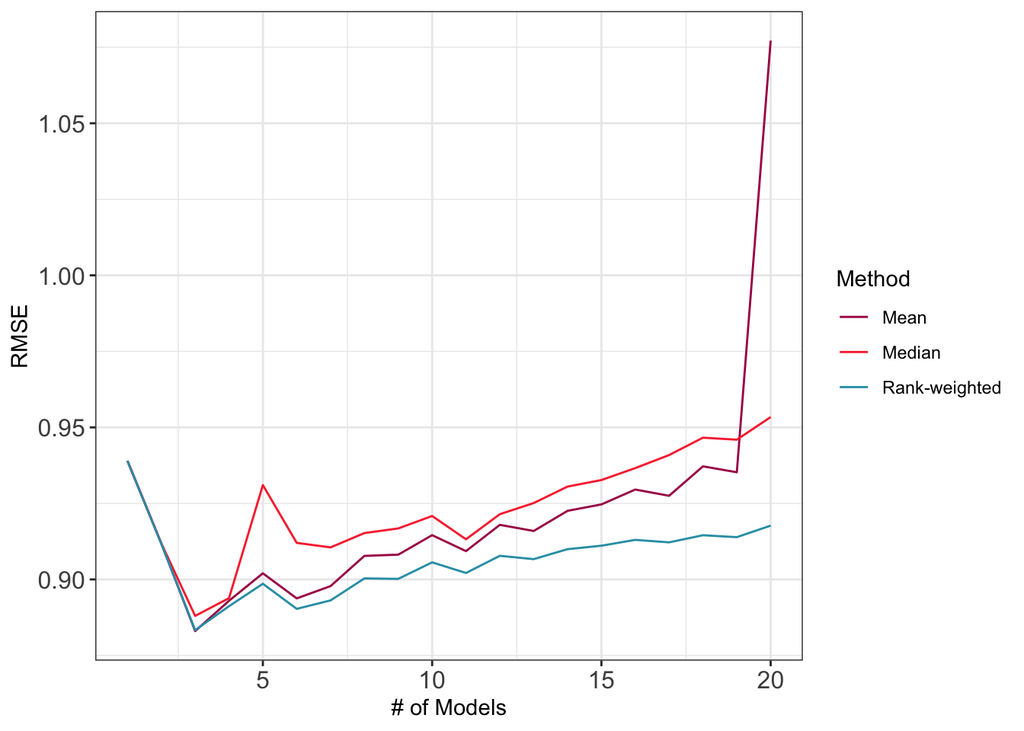

```r
ensemble_scores <- bind_rows(median_results_rmse, mean_results_rmse, rank_results_rmse)  %>%
  set_names(c("ensemble_model", "score", "iteration")) %>%
  mutate(iteration = as.numeric(iteration))

ggplot(data = ensemble_scores %>% filter(grepl("*rmse*", ensemble_model))) +
  geom_line(aes(x= iteration, y = score, color = ensemble_model)) +
  scale_color_manual(values = c("#AA1155","#F8333C","#2B9EB3"),
                     name = "Method",
                     labels = c("Mean", "Median", "Rank-weighted")) +
  theme_bw() +
  labs(x = "# of Models", y = "RMSE") +
  theme(axis.text = element_text(size = 12))
```

plot the best vs gold standard where the 3rd ensemble is the best:

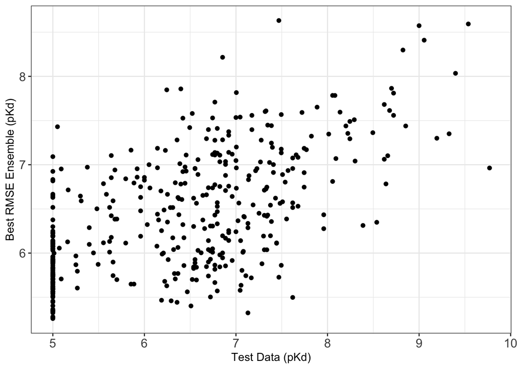

```r
best_ens_vs_gold <- mean_preds_rm %>%
  left_join(gold) %>%
  select(1:6, rmse_mean_ensemble_3, `pKd_[M]`) %>%
  mutate(gold = `pKd_[M]`)

ggplot(data = best_ens_vs_gold)  +
  geom_point(aes(x= gold, y= rmse_mean_ensemble_3)) +
  theme_bw() +
  labs(x = "Test Data (pKd)", y = "Best RMSE Ensemble (pKd)") +
  theme(axis.text = element_text(size = 12))
```

Then, we score all of these predictions using a bootstrap function from the `challengescoring` package. We’ll calculate Bayes factors using the first ‘ensemble’ (i.e. the top method only) as reference for “best” prediction to assess whether it’s substantially different from its neighboring ensembles.

spearman:

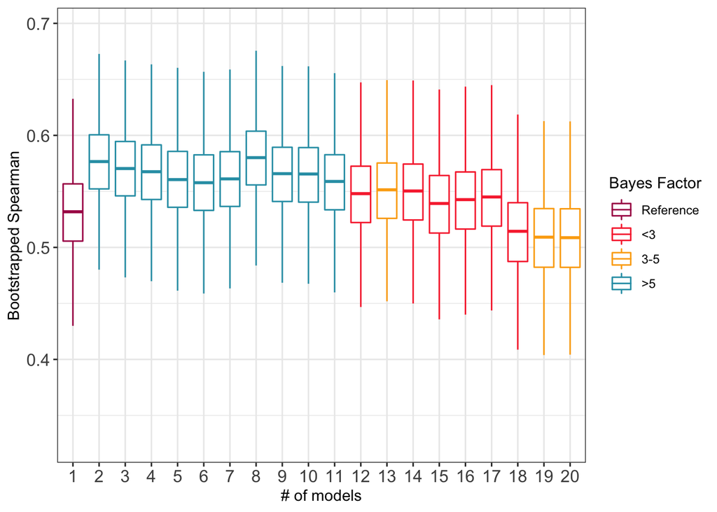

```r
computeBayesFactorWhereRefIsNotBest <- function(bootstrapMetricMatrix,
                               refPredIndex,
                               invertBayes){

    M <- as.data.frame(bootstrapMetricMatrix - bootstrapMetricMatrix[,refPredIndex])
    K <- apply(M ,2, function(x) {
      k <- sum(x >= 0)/sum(x < 0)
      if(sum(x >= 0) > sum(x < 0)){
      return(k)
      }else{
      return(1/k)
      }
    })
    if(invertBayes == T){K <- 1/K}
    K[refPredIndex] <- 0

    return(K)
}


ens_spearman_mean_bs <- finalScoring(predictions = mean_preds_sp %>% select(-spearman_mean_ensemble_1),
                         predictionColname = NA,
                         predictionIds = colnames(mean_preds_sp %>% select(-spearman_mean_ensemble_1))[7:58],
                         goldStandard = gold,
                         goldStandardColname = 'pKd_[M]',
                         bestPrediction =  mean_preds_sp %>% select(1:6,spearman_mean_ensemble_1),
                         bestPredictionId = "spearman_mean_ensemble_1",
                         keyColumns = colnames(gold)[1:6],
                         doParallel = TRUE,
                         scoreFun = spearman_py,
                         largerIsBetter = T)

bayesredo <- computeBayesFactorWhereRefIsNotBest(ens_spearman_mean_bs$bootstrappedScores,
                                                 1, F)

tidy_bayes <- tibble('iteration' = colnames(ens_spearman_mean_bs$bootstrappedScores),
                         'bayes' = bayesredo)

tidy_res <- ens_spearman_mean_bs$bootstrappedScores %>%
  as.data.frame %>%
  tidyr::gather(iteration, bootstrappedScore) %>%
  left_join(tidy_bayes) %>%
  mutate(iteration = stringr::str_extract(iteration, "[:digit:]+") %>% as.numeric %>% as.factor)

ggplot(data = tidy_res) +
  geom_boxplot(aes(x = iteration, y = bootstrappedScore,
                   color = cut(bayes, c(-1,0, 3, 5,Inf), include.lowest = T, ordered_result = T, right = T)), outlier.shape = NA)+
  scale_color_manual(values = c("#AA1155","#F8333C","#FCAB10","#2B9EB3"),
                     name = "Bayes Factor",
                     labels = c("Reference", "<3","3-5",">5")) +
  labs(x = "# of models", y = "Bootstrapped Spearman") +
  theme_bw() +
  theme(axis.text = element_text(size = 12))
```

RMSE:

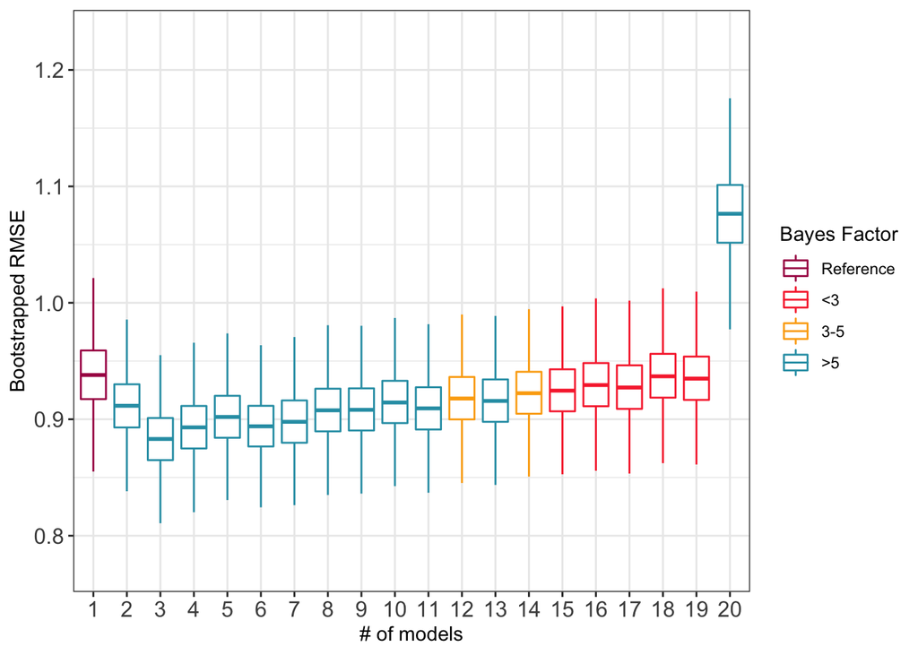

```r
ens_rmse_mean_bs <- finalScoring(predictions = mean_preds_rm %>% select(-rmse_mean_ensemble_1),
                         predictionColname = NA,
                         predictionIds = colnames(mean_preds_rm %>% select(-rmse_mean_ensemble_1))[7:58],
                         goldStandard = gold,
                         goldStandardColname = 'pKd_[M]',
                         bestPrediction =  mean_preds_rm %>% select(1:6,rmse_mean_ensemble_1),
                         bestPredictionId = "rmse_mean_ensemble_1",
                         keyColumns = colnames(gold)[1:6],
                         doParallel = TRUE,
                         scoreFun = rmse_py,
                         largerIsBetter = T)

bayesredo <- computeBayesFactorWhereRefIsNotBest(ens_rmse_mean_bs$bootstrappedScores,
                                                 1, F)

tidy_bayes <- tibble('iteration' = colnames(ens_rmse_mean_bs$bootstrappedScores),
                         'bayes' = bayesredo)

tidy_res <- ens_rmse_mean_bs$bootstrappedScores %>%
  as.data.frame %>%
  tidyr::gather(iteration, bootstrappedScore) %>%
  left_join(tidy_bayes) %>%
  mutate(iteration = stringr::str_extract(iteration, "[:digit:]+") %>% as.numeric %>% as.factor)

ggplot(data = tidy_res) +
  geom_boxplot(aes(x = iteration, y = bootstrappedScore,
                   color = cut(bayes, c(-1,0, 3, 5,Inf), include.lowest = T, ordered_result = T, right = T)), outlier.shape = NA)+
  scale_color_manual(values = c("#AA1155","#F8333C","#FCAB10","#2B9EB3"),
                     name = "Bayes Factor",
                     labels = c("Reference", "<3","3-5",">5")) +
  labs(x = "# of models", y = "Bootstrapped RMSE") +
  theme_bw() +
  theme(axis.text = element_text(size = 12))
```